# Exam 3

## Data Visualization and Analysis of Two Distinct Data Sets

### Data Set 1: College Faculty Salaries in 1995

Displayed below is a plot showing the relationship between salary, position, and college tier as well as a summary of an ANOVA model that tests the influence of state, tier, and rank on salary without testing interactions between those predictors.

```r
library(tidyverse)
library(broom)
```

```r
df <- read.csv("FacultySalaries_1995.csv")
assist <- df %>%
  pivot_longer(cols = AvgAssistProfSalary,
               names_to = "Rank",
               values_to = "Salary",
               values_drop_na = TRUE) %>%
  mutate(Rank = Rank %>% str_remove("ProfSalary") %>% str_remove("Avg"))
assoc <- df %>%
  pivot_longer(cols = AvgAssocProfSalary,
               names_to = "Rank",
               values_to = "Salary",
               values_drop_na = TRUE) %>%
  mutate(Rank = Rank %>% str_remove("ProfSalary") %>% str_remove("Avg"))
full <- df %>%
    pivot_longer(cols = AvgFullProfSalary,
               names_to = "Rank",
               values_to = "Salary",
               values_drop_na = TRUE) %>%
  mutate(Rank = Rank %>% str_remove("ProfSalary") %>% str_remove("Avg"))
join <-
  full %>%
  full_join(assoc) %>%
  full_join(assist)
```

##### **Plot Summary**

While the plot to the right does not give us accurate salary values, it is valuable to see differences in salary between groups and the influence of predictors on salary.

There is a visible increase in median salary with higher rank and college tiers prioritizing research. The plot also shows that there is more variance in the salary of full professors.

##### **ANOVA Test**

An ANOVA is used to compare the means between multiple groups to determine statistically whether the predictors of salary are significant.

*The results below show that state, tier, and rank have a p-value close to zero which means that each of these categories are significant predictors of professor salary.*

```r
aov(data = join,
    formula = Salary ~ State + Tier + Rank) %>%
  summary()
```

```
##               Df   Sum Sq Mean Sq F value Pr(>F)
## State         51  5682396  111420   30.66 <2e-16 ***
## Tier           2  7072361 3536180  972.96 <2e-16 ***
## Rank           2 16529771 8264885 2274.04 <2e-16 ***
## Residuals   3299 11990072    3634
## ---
## Signif. codes:  0 '***' 0.001 '**' 0.01 '*' 0.05 '.' 0.1 ' ' 1
```

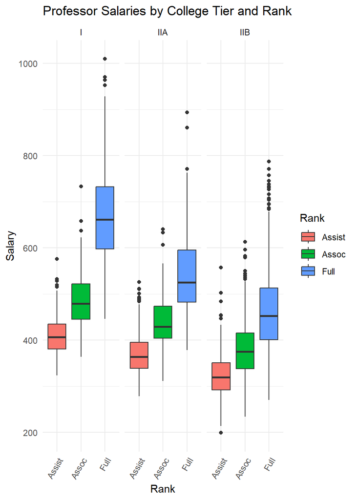

```r
join %>%
  filter(Tier != "VIIB") %>%
  ggplot(aes(x=Rank,y=Salary,fill=Rank)) +
  geom_boxplot() +
  facet_wrap(~Tier) +
  theme_minimal() +
  theme(axis.text.x = element_text(angle = 60, hjust = 1)) +
  ggtitle("Professor Salaries by College Tier and Rank")
```

### Data Set 2: Mass Spectroscopy of Chemical Concentrations in Cedar Trees that have Died due to Forest Fire

This data set was gathered by teams at Young Living Inc. and UVU Microbiology. Displayed below is a plot of the concentration of various chemicals in cedar trees that have burned. The curve represents chemical concentration over time in years.

```r
dat <- read.csv("Juniper_Oils.csv") %>%
  pivot_longer(cols = c("alpha.pinene","para.cymene","alpha.terpineol","cedr.9.ene","alpha.cedrene","beta.cedrene","cis.thujopsene","alpha.himachalene","beta.chamigrene","cuparene","compound.1","alpha.chamigrene","widdrol","cedrol","beta.acorenol","alpha.acorenol","gamma.eudesmol","beta.eudesmol","alpha.eudesmol","cedr.8.en.13.ol","cedr.8.en.15.ol","compound.2","thujopsenal"),
               names_to = "ChemicalID",
               values_to = "Concentration")
```

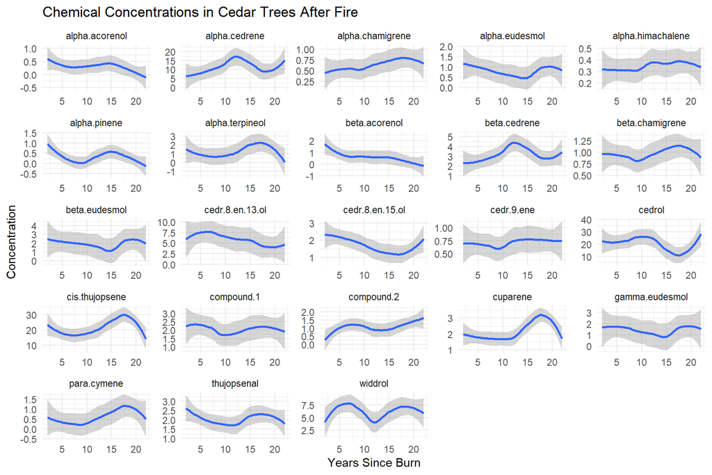

```r
dat %>%
  ggplot(aes(x=YearsSinceBurn,y=Concentration)) +
  geom_smooth() +
  facet_wrap(~ChemicalID,scales='free') +
  theme_minimal() +
  ggtitle("Chemical Concentrations in Cedar Trees After Fire") +
  labs(x="Years Since Burn")
```

##### **Chemicals Significantly Affected by Time**

The plot above shows that there is a change in chemical concentrations over time, but to determine if any chemicals have a statistically significant change in concentration over time, we can model the affect and summarize the components of the model, including the p-values of predictors.

Shown below are the results of linear modeling the affects of time on concentration of each chemical and the interactive terms between time in years and chemical type.

The interaction between time in years and cis-thujopsene also appears to be significant.

```r
model <- glm(data = dat,
             formula = Concentration ~ YearsSinceBurn * ChemicalID)
significant_chemicals <- tidy(model) %>%
  filter(p.value < 0.05) %>%
  mutate(term = gsub("ChemicalID", "", term)) %>%
  print
```

```
## # A tibble: 6 × 5
##   term                          estimate std.error statistic  p.value
##   <chr>                            <dbl>     <dbl>     <dbl>    <dbl>
## 1 alpha.cedrene                    7.88      1.93       4.08 4.97e- 5
## 2 cedr.8.en.13.ol                  7.62      1.93       3.95 8.72e- 5
## 3 cedrol                          22.5       1.93      11.7  5.12e-29
## 4 cis.thujopsene                  17.3       1.93       8.95 2.93e-18
## 5 widdrol                          5.82      1.93       3.01 2.69e- 3
## 6 YearsSinceBurn:cis.thujopsene    0.332     0.141      2.35 1.90e- 2
```